# EFA for parent scales

Ale Garcia

2025-02-11

## From Flora, LaBrish, & Chalmers (2012)

Check collineraity: “refers to perfect or near-perfect linear relationships among observed variables. With multiple regression, the focus is on collinearity among explanatory variables, but with factor analysis, the concern is collinearity among dependent variables, that is, the set of variables being factor analyzed. When collinear variables are included, the product-moment correlation matrix R will be singular, or non-positive definite.”

“Collinearity in factor analysis is relatively simple to diagnose: if any eigen values of a product-moment R equal zero or are negative, then R is non-positive definite and collinearity is present (and software will likely produce a warning message).”

Heywood cases: “Improper solutions (e.g.,a model solution with at least one negative estimated residual variance term, or“Heywoodcase”) are also likely to occur in the presence of one or more unusual cases (Bollen, 1987), which can lead to a researcher unwittingly revising a model or removing an observed variable from the analysis.”

Multicollenearity will produce 1 of 2 things: - aberrant factorial load - negative variance (more for CFA) - non-positive definite matrix. - Check for collinearity between items included on an EFA model using the correlation plot

### Rationale for factor extraction method and type of rotation.

Since Juntos assessments variables targeted for EFA were ordinal (4- and 5-point Likert response scales) and EFA of Pearson product-moment correlation among polytomous variables can produce misleading results (Flora et al., 2012), a polychoric correlation approach was used in this dissertation. An unweighted least squares (ULS) estimation method was used for EFA as recommended by Flora et al. (2012). To determine the number of factors to retain in each scale, examination of scree plots, Kaiser’s rule (eigenvalues > 1), parallel analysis, and analysis of the pattern of factor loadings were considered. If more than one factor emerged in a given scale, an oblique quartimin rotation was used as suggested by Flora et al. (2012). To reach a simple factor structure, items with factor loadings that fell below .3 and items with cross-loadings on more than one factor were discarded.

### Steps to identify # of factors

1. Evaluate multicollinearity with matrix polychoric
2. Check kmo
3. Observe scree plot and eigen values
4. Conduct parallel analysis (ideally with no warning messages, but if there are, it’s ok). If it shows more factors than sensible: look for communality above .4 (h2); factor loading above 0.4;
5. Run fa() with number of factors that seem reasonable. Warnings are UNacceptable and changes in the scale need to be done.

# The dataset

```r
parent_w1 <- read_sav(here("outcomes paper/data_outcomes", "primary_parent_w1.sav"))
# 95 cases, primary parent only
```

# Homework Involvement

conteste la frecuencia con la que ha hecho lo siguiente para ayudarle a su hija/o con la tarea en los últimos tres meses… 84 Me aseguré de que tenga un cierto tiempo para hacer la tarea 85 Me aseguré de que él / ella tenga un cierto lugar para hacer la tarea 86 Me senté con mi joven mientras él / ella hacía su tarea 87 Me hice disponible para mi joven cuando tenía preguntas sobre su tarea 88 Ayudé a mi joven cuando estaba atascado/a en una tarea 89 Ayudé a mi joven a prepararse para los exámenes haciéndole preguntas sobre el tema, etc. 90 Le di a mi joven incentivos como privilegios especiales, regalos especiales, etc. 91 Utilicé consecuencias, castigos, acciones disciplinarias 92 Le recordé a mi joven que hiciera su tarea 93 Comprobé con mi joven para asegurarme de que él / ella hiciera su tarea 94 Comprobé y corregí la tarea de mi hija/o 95 Comprobé con la maestra/o para asegurarme que mi joven terminó su tarea 96 Le ayudé a mi joven acceder a otros recursos (biblioteca, materiales de arte, laboratorio de computación, etc.) 97 Le ayudé a mi joven practicar habilidades (lectura, revisión, problemas de práctica, etc.) 98 Limité el ruido y/o las distracciones mientras hacia su tarea

## The scale to factor analyze

```r
hw_inv <- parent_w1 %>%
  select(q84, q85, q86, q87, q88, q89, q90, q91, q92, q93, q94, q95, q96, q97, q98)
```

## kmo Kaiser-Meyer-Olkin factor sampling adequacy (above 0.5, closer 1 is best)

```r
KMO(hw_inv) # 0.71 --> ok
```

```
## Kaiser-Meyer-Olkin factor adequacy
## Call: KMO(r = hw_inv)
## Overall MSA =  0.71
## MSA for each item =
##  q84  q85  q86  q87  q88  q89  q90  q91  q92  q93  q94  q95  q96  q97  q98
## 0.61 0.64 0.84 0.72 0.73 0.81 0.64 0.52 0.50 0.74 0.75 0.76 0.82 0.66 0.73
```

## Poly corr matrix

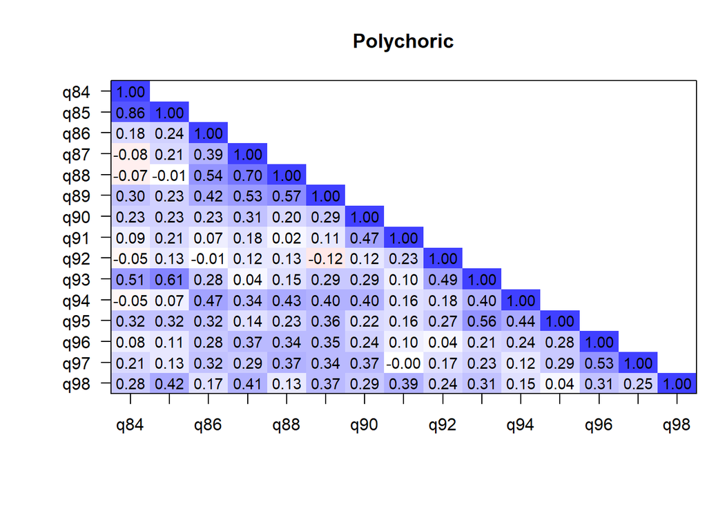

```r
poly <- polychoric(hw_inv)
cor.plot(poly$rho, numbers = T, upper = F, main = "Polychoric", show.legend = F)
```

```r
# items 84, 89 neg corr with other items
# 84    Me aseguré de que tenga un cierto tiempo para hacer la tarea
# 89    Ayudé a mi joven a prepararse para los exámenes haciéndole preguntas sobre el tema, etc.
```

## scree plot

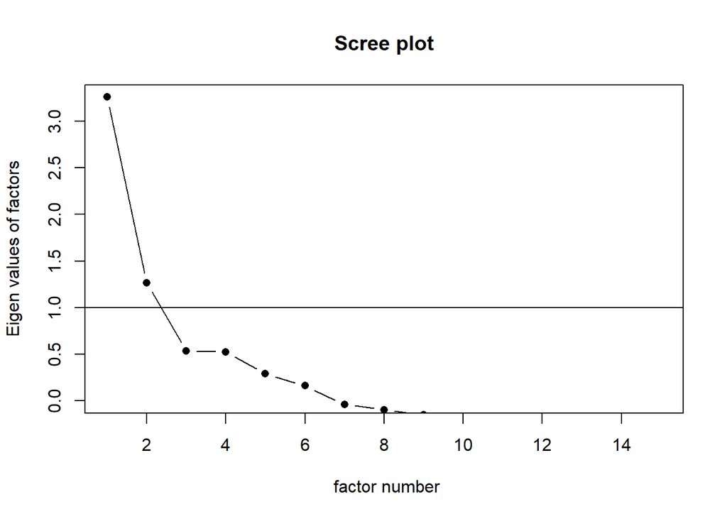

```r
scree(hw_inv, factors = TRUE, pc = FALSE, main = "Scree plot", hline = NULL, add = FALSE)
```

```r
# Scree plot shows 3 factor solution, but 1 eigenvalue would be less than 1.0
```

## EFA using ULS 1 factor

```r
factor_test_uls <- fa(hw_inv, n.obs = 95, rotate = "oblimin", fm = "uls", cor = "poly", nfactors = 1)
factor_test_uls
```

```
## Factor Analysis using method =  uls
## Call: fa(r = hw_inv, nfactors = 1, n.obs = 95, rotate = "oblimin",
##     fm = "uls", cor = "poly")
## Standardized loadings (pattern matrix) based upon correlation matrix
##     ULS1    h2   u2 com
## q84 0.40 0.157 0.84   1
## q85 0.50 0.253 0.75   1
## q86 0.58 0.336 0.66   1
## q87 0.58 0.332 0.67   1
## q88 0.56 0.319 0.68   1
## q89 0.67 0.448 0.55   1
## q90 0.53 0.276 0.72   1
## q91 0.30 0.087 0.91   1
## q92 0.25 0.063 0.94   1
## q93 0.60 0.358 0.64   1
## q94 0.55 0.302 0.70   1
## q95 0.55 0.303 0.70   1
## q96 0.50 0.254 0.75   1
## q97 0.52 0.266 0.73   1
## q98 0.50 0.251 0.75   1
##
##                ULS1
## SS loadings    4.01
## Proportion Var 0.27
##
## Mean item complexity =  1
## Test of the hypothesis that 1 factor is sufficient.
##
## df null model =  105  with the objective function =  9.91 with Chi Square =  873.73
## df of  the model are 90  and the objective function was  7.04
##
## The root mean square of the residuals (RMSR) is  0.15
## The df corrected root mean square of the residuals is  0.17
##
## The harmonic n.obs is  93 with the empirical chi square  467.85  with prob <  2.1e-52
## The total n.obs was  95  with Likelihood Chi Square =  615.67  with prob <  2.7e-79
##
## Tucker Lewis Index of factoring reliability =  0.195
## RMSEA index =  0.248  and the 90 % confidence intervals are  0.231 0.268
## BIC =  205.82
## Fit based upon off diagonal values = 0.75
## Measures of factor score adequacy
##                                                   ULS1
## Correlation of (regression) scores with factors   0.92
## Multiple R square of scores with factors          0.86
## Minimum correlation of possible factor scores     0.71
```

## EFA using ULS 2 factors

```r
factor_test_uls <- fa(hw_inv, n.obs = 95, rotate = "oblimin", fm = "uls", cor = "poly", nfactors = 2)
factor_test_uls
```

```
## Factor Analysis using method =  uls
## Call: fa(r = hw_inv, nfactors = 2, n.obs = 95, rotate = "oblimin",
##     fm = "uls", cor = "poly")
## Standardized loadings (pattern matrix) based upon correlation matrix
##      ULS1  ULS2    h2   u2 com
## q84 -0.12  0.84 0.689 0.31 1.0
## q85 -0.02  0.90 0.796 0.20 1.0
## q86  0.57  0.13 0.371 0.63 1.1
## q87  0.74 -0.06 0.540 0.46 1.0
## q88  0.84 -0.18 0.691 0.31 1.1
## q89  0.64  0.18 0.482 0.52 1.1
## q90  0.38  0.28 0.262 0.74 1.8
## q91  0.16  0.23 0.091 0.91 1.8
## q92  0.12  0.22 0.070 0.93 1.6
## q93  0.19  0.70 0.566 0.43 1.1
## q94  0.56  0.09 0.343 0.66 1.0
## q95  0.33  0.40 0.311 0.69 1.9
## q96  0.51  0.09 0.282 0.72 1.1
## q97  0.47  0.16 0.270 0.73 1.2
## q98  0.30  0.36 0.258 0.74 1.9
##
##                       ULS1 ULS2
## SS loadings           3.34 2.69
## Proportion Var        0.22 0.18
## Cumulative Var        0.22 0.40
## Proportion Explained  0.55 0.45
## Cumulative Proportion 0.55 1.00
##
##  With factor correlations of
##      ULS1 ULS2
## ULS1 1.00 0.18
## ULS2 0.18 1.00
##
## Mean item complexity =  1.3
## Test of the hypothesis that 2 factors are sufficient.
##
## df null model =  105  with the objective function =  9.91 with Chi Square =  873.73
## df of  the model are 76  and the objective function was  5.14
##
## The root mean square of the residuals (RMSR) is  0.1
## The df corrected root mean square of the residuals is  0.12
##
## The harmonic n.obs is  93 with the empirical chi square  209.9  with prob <  1.8e-14
## The total n.obs was  95  with Likelihood Chi Square =  446.34  with prob <  8.3e-54
##
## Tucker Lewis Index of factoring reliability =  0.323
## RMSEA index =  0.226  and the 90 % confidence intervals are  0.207 0.248
## BIC =  100.25
## Fit based upon off diagonal values = 0.89
## Measures of factor score adequacy
##                                                   ULS1 ULS2
## Correlation of (regression) scores with factors   0.93 0.95
## Multiple R square of scores with factors          0.87 0.91
## Minimum correlation of possible factor scores     0.74 0.82
```

## new efa iteration without q90, q91, q92, q95, q98 -> below 0.3 loadings or cross-loading

90 Le di a mi joven incentivos como privilegios especiales, regalos especiales, etc. 91 Utilicé consecuencias, castigos, acciones disciplinarias 92 Le recordé a mi joven que hiciera su tarea 95 Comprobé con la maestra/o para asegurarme que mi joven terminó su tarea 98 Limité el ruido y/o las distracciones mientras hacia su tarea

```r
hw_inv_1 <- parent_w1 %>%
  select(q84, q85, q86, q87, q88, q89, q93, q94, q96, q97)
```

## Poly corr matrix

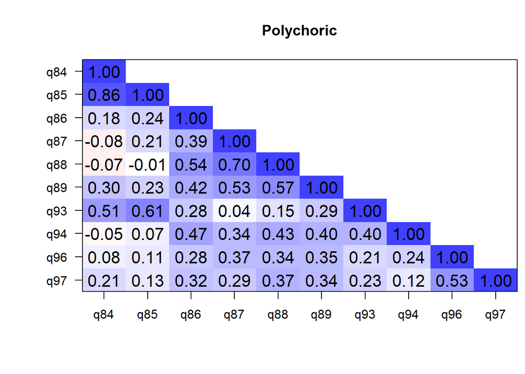

```r
poly <- polychoric(hw_inv_1)
cor.plot(poly$rho, numbers = T, upper = F, main = "Polychoric", show.legend = F) # looks better, 84 and 85 show some neg corr with other items.
```

## parallel test

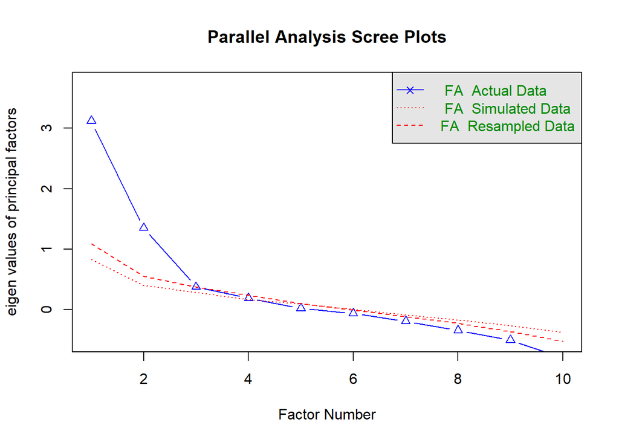

```
## Parallel analysis suggests that the number of factors =  3  and the number of components =  NA
```

```r
fa.parallel(hw_inv_1, n.obs=NULL, fm="uls", fa="fa", main="Parallel Analysis Scree Plots", cor="poly", use="pairwise", plot=TRUE)
```

```r
# Parallel analysis suggests that the number of factors =  3, multiple warnings
```

## EFA using ULS 2 factors

```r
factor_test_uls <- fa(hw_inv_1, n.obs = 95, rotate = "oblimin", fm = "uls", cor = "poly", nfactors = 2)
factor_test_uls
```

```
## Factor Analysis using method =  uls
## Call: fa(r = hw_inv_1, nfactors = 2, n.obs = 95, rotate = "oblimin",
##     fm = "uls", cor = "poly")
## Standardized loadings (pattern matrix) based upon correlation matrix
##      ULS1  ULS2   h2   u2 com
## q84 -0.08  0.95 0.89 0.11 1.0
## q85  0.04  0.90 0.83 0.17 1.0
## q86  0.60  0.16 0.42 0.58 1.1
## q87  0.73 -0.06 0.52 0.48 1.0
## q88  0.88 -0.14 0.76 0.24 1.1
## q89  0.66  0.20 0.51 0.49 1.2
## q93  0.22  0.59 0.43 0.57 1.3
## q94  0.53  0.04 0.29 0.71 1.0
## q96  0.50  0.08 0.26 0.74 1.1
## q97  0.46  0.15 0.25 0.75 1.2
##
##                       ULS1 ULS2
## SS loadings           2.93 2.23
## Proportion Var        0.29 0.22
## Cumulative Var        0.29 0.52
## Proportion Explained  0.57 0.43
## Cumulative Proportion 0.57 1.00
##
##  With factor correlations of
##      ULS1 ULS2
## ULS1 1.00 0.13
## ULS2 0.13 1.00
##
## Mean item complexity =  1.1
## Test of the hypothesis that 2 factors are sufficient.
##
## df null model =  45  with the objective function =  6.37 with Chi Square =  572.62
## df of  the model are 26  and the objective function was  2.21
##
## The root mean square of the residuals (RMSR) is  0.08
## The df corrected root mean square of the residuals is  0.1
##
## The harmonic n.obs is  93 with the empirical chi square  51.24  with prob <  0.0022
## The total n.obs was  95  with Likelihood Chi Square =  195.2  with prob <  7.3e-28
##
## Tucker Lewis Index of factoring reliability =  0.436
## RMSEA index =  0.262  and the 90 % confidence intervals are  0.229 0.298
## BIC =  76.8
## Fit based upon off diagonal values = 0.95
## Measures of factor score adequacy
##                                                   ULS1 ULS2
## Correlation of (regression) scores with factors   0.94 0.97
## Multiple R square of scores with factors          0.88 0.94
## Minimum correlation of possible factor scores     0.77 0.87
```

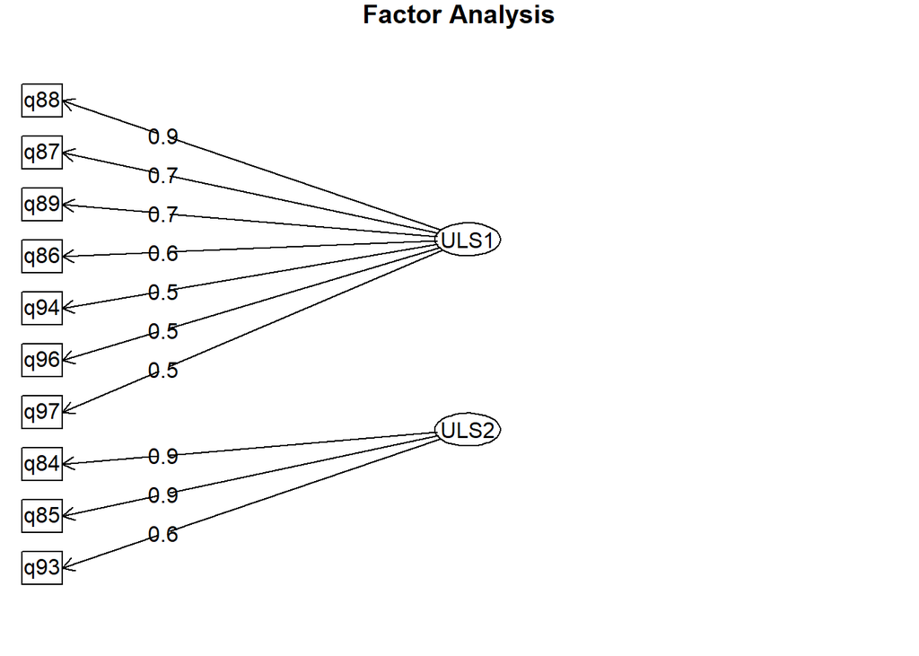

```r
fa.diagram(factor_test_uls)
```

## factor # 1: tutoring hwi

86 Me senté con mi joven mientras él / ella hacía su tarea 87 Me hice disponible para mi joven cuando tenía preguntas sobre su tarea 88 Ayudé a mi joven cuando estaba atascado/a en una tarea 89 Ayudé a mi joven a prepararse para los exámenes haciéndole preguntas sobre el tema, etc 94 Comprobé y corregí la tarea de mi hija/o 96 Le ayudé a mi joven acceder a otros recursos (biblioteca, materiales de arte, laboratorio de computación, etc.) 97 Le ayudé a mi joven practicar habilidades (lectura, revisión, problemas de práctica, etc.)

```r
hw_inv_fa1 <- parent_w1 %>%
  select(q86, q87, q88, q89, q94, q96, q97)

# alpha
alpha(hw_inv_fa1) # 0.78
```

```
##
## Reliability analysis
## Call: alpha(x = hw_inv_fa1)
##
##   raw_alpha std.alpha G6(smc) average_r S/N   ase mean   sd median_r
##       0.78      0.78    0.78      0.34 3.5 0.035  2.7 0.67     0.33
##
##     95% confidence boundaries
##          lower alpha upper
## Feldt     0.70  0.78  0.84
## Duhachek  0.71  0.78  0.84
##
##  Reliability if an item is dropped:
##     raw_alpha std.alpha G6(smc) average_r S/N alpha se  var.r med.r
## q86      0.74      0.75    0.74      0.33 3.0    0.041 0.0129  0.32
## q87      0.74      0.74    0.73      0.33 2.9    0.041 0.0099  0.33
## q88      0.72      0.72    0.70      0.30 2.6    0.044 0.0069  0.30
## q89      0.74      0.75    0.74      0.33 2.9    0.041 0.0144  0.32
## q94      0.77      0.77    0.76      0.36 3.4    0.037 0.0096  0.33
## q96      0.76      0.76    0.75      0.35 3.2    0.038 0.0126  0.34
## q97      0.76      0.77    0.75      0.35 3.3    0.038 0.0099  0.34
##
##  Item statistics
##      n raw.r std.r r.cor r.drop mean   sd
## q86 94  0.65  0.67  0.60   0.53  2.8 0.91
## q87 93  0.67  0.69  0.63   0.55  3.4 0.88
## q88 92  0.76  0.76  0.74   0.64  3.0 1.03
## q89 94  0.69  0.68  0.59   0.53  2.3 1.20
## q94 92  0.58  0.58  0.47   0.41  2.3 1.04
## q96 94  0.63  0.61  0.52   0.44  2.6 1.10
## q97 94  0.60  0.59  0.49   0.43  2.7 0.97
##
## Non missing response frequency for each item
##        1    2    3    4 miss
## q86 0.11 0.21 0.46 0.22 0.01
## q87 0.06 0.08 0.28 0.58 0.02
## q88 0.13 0.13 0.34 0.40 0.03
## q89 0.37 0.18 0.21 0.23 0.01
## q94 0.30 0.26 0.30 0.13 0.03
## q96 0.23 0.19 0.33 0.24 0.01
## q97 0.17 0.16 0.48 0.19 0.01
```

## factor # 2: checking hwi

84 Me aseguré de que tenga un cierto tiempo para hacer la tarea 85 Me aseguré de que él / ella tenga un cierto lugar para hacer la tarea 93 Comprobé con mi joven para asegurarme de que él / ella hiciera su tarea

```r
hw_inv_fa2 <- parent_w1 %>%
  select(q84, q85, q93)
# alpha
alpha(hw_inv_fa2) # 0.77
```

```
##
## Reliability analysis
## Call: alpha(x = hw_inv_fa2)
##
##   raw_alpha std.alpha G6(smc) average_r S/N   ase mean   sd median_r
##       0.74      0.77    0.73      0.53 3.3 0.047  3.6 0.66     0.46
##
##     95% confidence boundaries
##          lower alpha upper
## Feldt     0.64  0.74  0.82
## Duhachek  0.65  0.74  0.84
##
##  Reliability if an item is dropped:
##     raw_alpha std.alpha G6(smc) average_r S/N alpha se var.r med.r
## q84      0.62      0.63    0.46      0.46 1.7    0.075    NA  0.46
## q85      0.52      0.55    0.38      0.38 1.2    0.090    NA  0.38
## q93      0.85      0.85    0.74      0.74 5.7    0.030    NA  0.74
##
##  Item statistics
##      n raw.r std.r r.cor r.drop mean   sd
## q84 92  0.81  0.85  0.79   0.63  3.7 0.67
## q85 94  0.86  0.89  0.84   0.69  3.7 0.76
## q93 94  0.80  0.74  0.50   0.45  3.3 0.97
##
## Non missing response frequency for each item
##        1    2    3    4 miss
## q84 0.03 0.02 0.14 0.80 0.03
## q85 0.05 0.02 0.10 0.83 0.01
## q93 0.09 0.10 0.21 0.61 0.01
```

## Omega

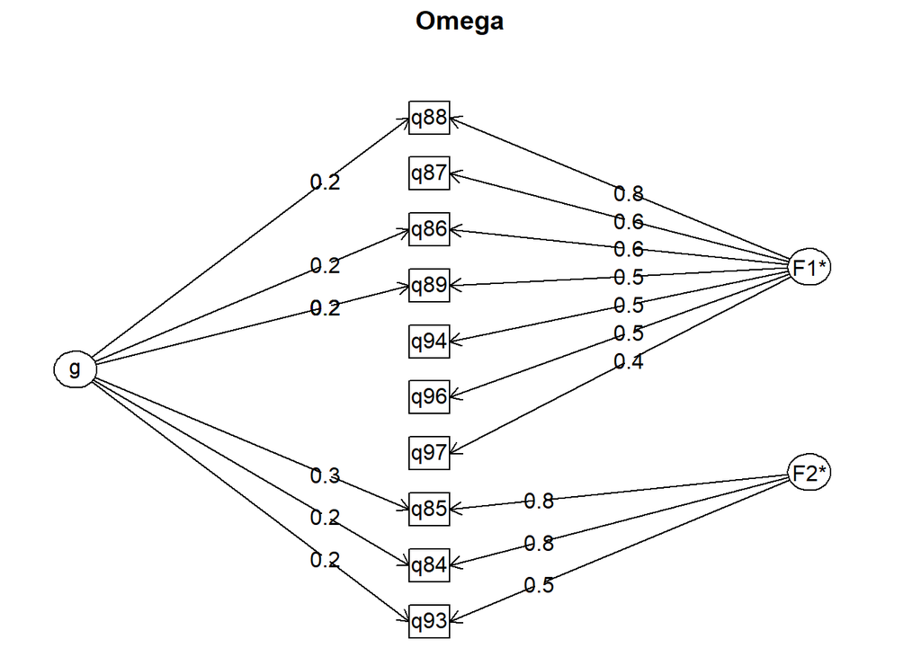

```
## Omega
## Call: omegah(m = m, nfactors = nfactors, fm = fm, key = key, flip = flip,
##     digits = digits, title = title, sl = sl, labels = labels,
##     plot = plot, n.obs = n.obs, rotate = rotate, Phi = Phi, option = option,
##     covar = covar)
## Alpha:                 0.76
## G.6:                   0.81
## Omega Hierarchical:    0.13
## Omega H asymptotic:    0.16
## Omega Total            0.82
##
## Schmid Leiman Factor loadings greater than  0.2
##         g   F1*   F2*   h2   h2   u2   p2  com
## q84  0.23        0.80 0.70 0.70 0.30 0.08 1.18
## q85  0.27        0.82 0.74 0.74 0.26 0.10 1.21
## q86  0.21  0.56       0.36 0.36 0.64 0.12 1.32
## q87        0.63       0.43 0.43 0.57 0.07 1.18
## q88  0.21  0.77       0.65 0.65 0.35 0.07 1.19
## q89  0.23  0.55       0.39 0.39 0.61 0.14 1.59
## q93  0.20        0.48 0.30 0.30 0.70 0.14 1.62
## q94        0.45       0.24 0.24 0.76 0.12 1.33
## q96        0.45       0.24 0.24 0.76 0.12 1.35
## q97        0.43       0.24 0.24 0.76 0.14 1.69
##
## With Sums of squares  of:
##    g  F1*  F2*   h2
## 0.43 2.22 1.64 2.20
##
## general/max  0.19   max/min =   1.35
## mean percent general =  0.11    with sd =  0.03 and cv of  0.26
## Explained Common Variance of the general factor =  0.1
##
## The degrees of freedom are 26  and the fit is  0.41
## The number of observations was  95  with Chi Square =  35.9  with prob <  0.094
## The root mean square of the residuals is  0.06
## The df corrected root mean square of the residuals is  0.08
## RMSEA index =  0.062  and the 10 % confidence intervals are  0 0.11
## BIC =  -82.5
##
## Compare this with the adequacy of just a general factor and no group factors
## The degrees of freedom for just the general factor are 35  and the fit is  2.46
## The number of observations was  95  with Chi Square =  219.53  with prob <  1.4e-28
## The root mean square of the residuals is  0.26
## The df corrected root mean square of the residuals is  0.3
##
## RMSEA index =  0.235  and the 10 % confidence intervals are  0.207 0.267
## BIC =  60.14
##
## Measures of factor score adequacy
##                                                   g  F1*  F2*
## Correlation of scores with factors             0.38 0.87 0.88
## Multiple R square of scores with factors       0.14 0.75 0.78
## Minimum correlation of factor score estimates -0.72 0.50 0.56
##
##  Total, General and Subset omega for each subset
##                                                  g  F1*  F2*
## Omega total for total scores and subscales    0.82 0.78 0.80
## Omega general for total scores and subscales  0.13 0.09 0.08
## Omega group for total scores and subscales    0.60 0.70 0.72
```

```r
omega(hw_inv_1, nfactors = 2, n.obs = 95, flip = T, plot = T) # alpha = 0.76
```

# structure

Los últimos tres meses, he tomado medidas para apoyar a mi joven a… 23. … desarrollar un plan para estudiar y hacer la tarea 24. … encontrar formas de involucrarse en las actividades escolares 25. … encontrar maneras de involucrarse en actividades de voluntario/a en la comunidad 26. … hacer metas para el año escolar 27. … cumplir fechas de limite 28. … participar en papeles de liderazgo en la escuela o comunidad 29. … enfocarse en hacer lo mejor posible 30. … desarrollar un horario para completar la tarea y los proyectos escolares a tiempo

## The scale to factor analyze

```r
struct <- parent_w1 %>%
  select(q23, q24, q25, q26, q27, q28, q29, q30)
```

## kmo Kaiser-Meyer-Olkin

```r
KMO(struct) # 0.76
```

```
## Kaiser-Meyer-Olkin factor adequacy
## Call: KMO(r = struct)
## Overall MSA =  0.76
## MSA for each item =
##  q23  q24  q25  q26  q27  q28  q29  q30
## 0.71 0.76 0.72 0.81 0.83 0.75 0.78 0.70
```

## Poly corr matrix

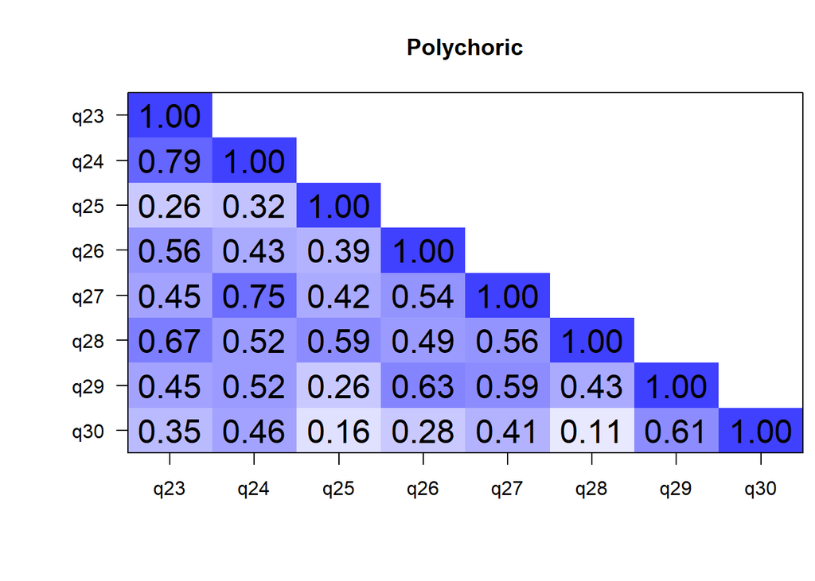

```r
poly <- polychoric(struct)
cor.plot(poly$rho, numbers = T, upper = F, main = "Polychoric", show.legend = F) # healthy corrs.
```

## scree plot

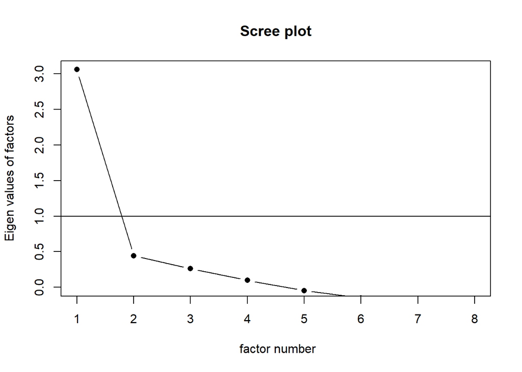

```r
scree(struct, factors = TRUE, pc = FALSE, main = "Scree plot", hline = NULL, add = FALSE)
```

```r
# Scree plot clearly shows 1 factor solution
```

## parallel test

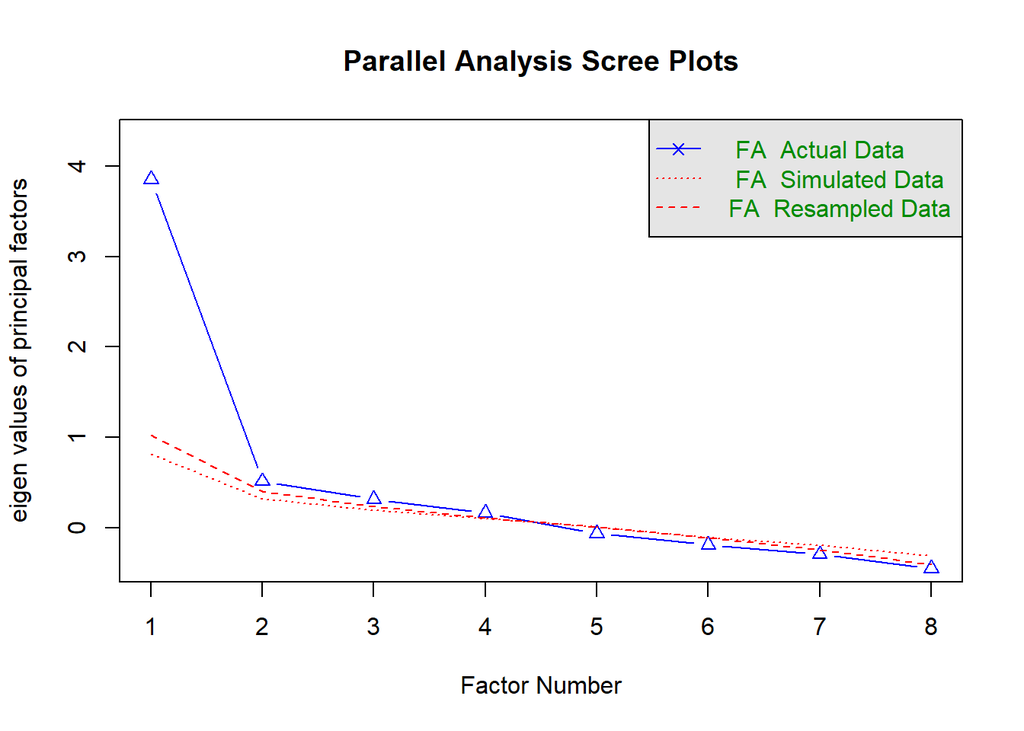

```
## Parallel analysis suggests that the number of factors =  4  and the number of components =  NA
```

```r
fa.parallel(struct, n.obs=NULL, fm="uls", fa="fa", main="Parallel Analysis Scree Plots", cor="poly", use="pairwise", plot=TRUE)
```

```r
# Parallel analysis suggests that the number of factors =  4, multiple warnings
```

## EFA using ULS - 2 factors

```r
factor_test_uls <- fa(struct, n.obs = 95, rotate = "oblimin", fm = "uls", cor = "poly", nfactors = 2)
factor_test_uls
```

```
## Factor Analysis using method =  uls
## Call: fa(r = struct, nfactors = 2, n.obs = 95, rotate = "oblimin",
##     fm = "uls", cor = "poly")
## Standardized loadings (pattern matrix) based upon correlation matrix
##     ULS1  ULS2   h2    u2 com
## q23 0.46  0.42 0.56 0.435 2.0
## q24 0.66  0.27 0.67 0.334 1.3
## q25 0.10  0.50 0.31 0.691 1.1
## q26 0.47  0.32 0.46 0.538 1.7
## q27 0.60  0.30 0.61 0.391 1.5
## q28 0.01  0.99 0.99 0.005 1.0
## q29 0.80  0.01 0.65 0.353 1.0
## q30 0.80 -0.27 0.52 0.483 1.2
##
##                       ULS1 ULS2
## SS loadings           2.77 2.00
## Proportion Var        0.35 0.25
## Cumulative Var        0.35 0.60
## Proportion Explained  0.58 0.42
## Cumulative Proportion 0.58 1.00
##
##  With factor correlations of
##      ULS1 ULS2
## ULS1 1.00 0.46
## ULS2 0.46 1.00
##
## Mean item complexity =  1.4
## Test of the hypothesis that 2 factors are sufficient.
##
## df null model =  28  with the objective function =  5.88 with Chi Square =  531.81
## df of  the model are 13  and the objective function was  2.08
##
## The root mean square of the residuals (RMSR) is  0.08
## The df corrected root mean square of the residuals is  0.11
##
## The harmonic n.obs is  94 with the empirical chi square  30.58  with prob <  0.0039
## The total n.obs was  95  with Likelihood Chi Square =  185.14  with prob <  1.5e-32
##
## Tucker Lewis Index of factoring reliability =  0.252
## RMSEA index =  0.373  and the 90 % confidence intervals are  0.328 0.424
## BIC =  125.94
## Fit based upon off diagonal values = 0.98
```

```r
# warnings. Too many crossloadings. one heywood case.
```

## EFA using ULS - 1 factor

```r
factor_test_uls <- fa(struct, n.obs = 95, rotate = "oblimin", fm = "uls", cor = "poly", nfactors = 1)
factor_test_uls
```

```
## Factor Analysis using method =  uls
## Call: fa(r = struct, nfactors = 1, n.obs = 95, rotate = "oblimin",
##     fm = "uls", cor = "poly")
## Standardized loadings (pattern matrix) based upon correlation matrix
##     ULS1   h2   u2 com
## q23 0.76 0.58 0.42   1
## q24 0.82 0.68 0.32   1
## q25 0.48 0.23 0.77   1
## q26 0.69 0.48 0.52   1
## q27 0.79 0.63 0.37   1
## q28 0.71 0.50 0.50   1
## q29 0.72 0.52 0.48   1
## q30 0.49 0.24 0.76   1
##
##                ULS1
## SS loadings    3.85
## Proportion Var 0.48
##
## Mean item complexity =  1
## Test of the hypothesis that 1 factor is sufficient.
##
## df null model =  28  with the objective function =  5.88 with Chi Square =  531.81
## df of  the model are 20  and the objective function was  2.55
##
## The root mean square of the residuals (RMSR) is  0.11
## The df corrected root mean square of the residuals is  0.13
##
## The harmonic n.obs is  94 with the empirical chi square  67.91  with prob <  4e-07
## The total n.obs was  95  with Likelihood Chi Square =  228.93  with prob <  2e-37
##
## Tucker Lewis Index of factoring reliability =  0.415
## RMSEA index =  0.331  and the 90 % confidence intervals are  0.295 0.373
## BIC =  137.85
## Fit based upon off diagonal values = 0.95
## Measures of factor score adequacy
##                                                   ULS1
## Correlation of (regression) scores with factors   0.95
## Multiple R square of scores with factors          0.90
## Minimum correlation of possible factor scores     0.80
```

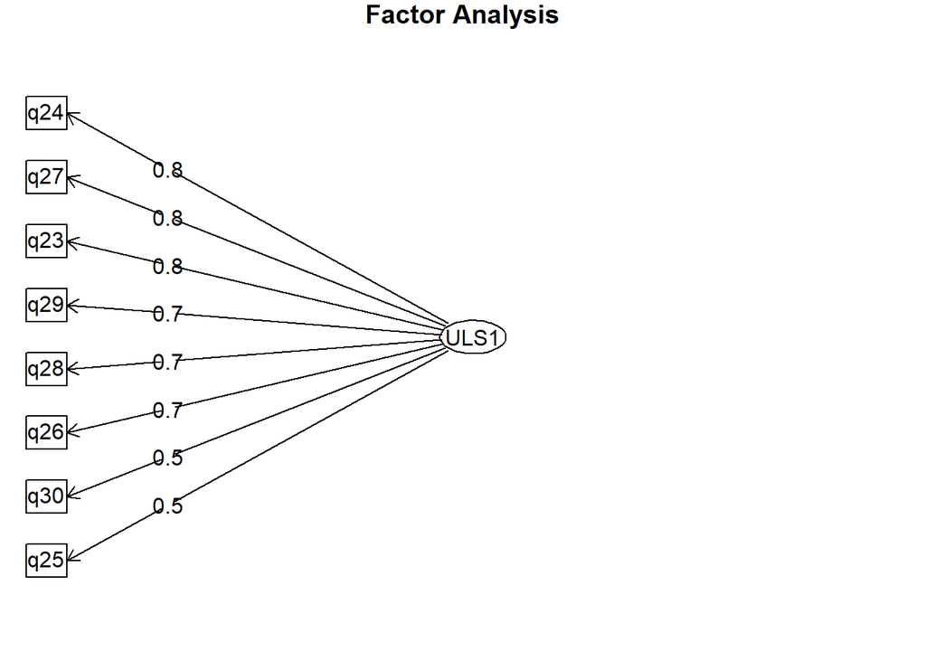

```r
fa.diagram(factor_test_uls)
```

```r
# no warnings. all loading above .30
```

## alpha

```r
alpha(struct) # 0.82
```

```
##
## Reliability analysis
## Call: alpha(x = struct)
##
##   raw_alpha std.alpha G6(smc) average_r S/N   ase mean   sd median_r
##       0.82      0.82    0.84      0.37 4.6 0.028  2.9 0.43     0.37
##
##     95% confidence boundaries
##          lower alpha upper
## Feldt     0.76  0.82  0.87
## Duhachek  0.77  0.82  0.88
##
##  Reliability if an item is dropped:
##     raw_alpha std.alpha G6(smc) average_r S/N alpha se var.r med.r
## q23      0.80      0.80    0.80      0.36 3.9    0.032 0.018  0.35
## q24      0.78      0.79    0.80      0.34 3.7    0.034 0.018  0.35
## q25      0.82      0.82    0.83      0.40 4.6    0.028 0.017  0.40
## q26      0.80      0.80    0.82      0.37 4.0    0.031 0.022  0.35
## q27      0.79      0.79    0.81      0.35 3.7    0.034 0.020  0.34
## q28      0.79      0.80    0.81      0.36 3.9    0.032 0.017  0.35
## q29      0.80      0.80    0.81      0.36 3.9    0.031 0.021  0.35
## q30      0.83      0.83    0.84      0.41 4.8    0.028 0.013  0.40
##
##  Item statistics
##      n raw.r std.r r.cor r.drop mean   sd
## q23 95  0.69  0.69  0.66   0.57  2.9 0.63
## q24 95  0.76  0.76  0.74   0.66  2.9 0.65
## q25 95  0.57  0.55  0.46   0.41  2.6 0.72
## q26 94  0.66  0.68  0.61   0.55  3.0 0.60
## q27 94  0.75  0.75  0.71   0.65  3.0 0.66
## q28 94  0.72  0.70  0.66   0.59  2.6 0.71
## q29 95  0.68  0.69  0.64   0.57  3.3 0.61
## q30 95  0.50  0.52  0.42   0.35  3.2 0.60
##
## Non missing response frequency for each item
##        1    2    3    4 miss
## q23 0.03 0.14 0.69 0.14 0.00
## q24 0.03 0.18 0.66 0.13 0.00
## q25 0.05 0.37 0.49 0.08 0.00
## q26 0.01 0.13 0.67 0.19 0.01
## q27 0.01 0.19 0.61 0.19 0.01
## q28 0.05 0.39 0.48 0.07 0.01
## q29 0.01 0.05 0.59 0.35 0.00
## q30 0.01 0.07 0.64 0.27 0.00
```

# convos with youth

en los últimos tres meses, usted ha tenido una conversación con su joven sobre… 68. … sus amistades en la escuela. *69. … su participación en actividades escolares.* _ 70. … eventos que van a pasar en la escuela. *71. … sus profesores.* 72. … las cosas que aprende en clase. *73. … cómo contribuye al salón de clase.* 74. … cómo va en sus clases. *75. … sus futuros objetivos de carrera y educación (incluso los objetivos a corto plazo).* _ 76. … desafíos que surgen en la escuela (como intimidación, agresión, acoso, racismo, peleas, etc.) *77. … sus actitudes sobre la escuela* _ 78. … su comportamiento en la escuela ____ 79. … las cosas que suceden en la escuela (el ambiente escolar en general) ____ 80. … la importancia de prepararse para futuras trayectorias educativas o de carrera, como la planificación universitaria y / o pensando acerca de la escuela técnica o comercial, etc. _____ 81. … su involucro en actividades extracurriculares en la escuela y en la comunidad como en papeles de liderazgo, haciendo trabajo voluntario en la comunidad, deportes, etc._____

## The scale to factor analyze

```r
convos <- parent_w1 %>%
  select(q68, q69, q70, q71, q72, q73, q74, q75, q76, q77, q78, q79, q80, q81)
```

## kmo Kaiser-Meyer-Olkin factor

```r
KMO(convos) # 0.86
```

```
## Kaiser-Meyer-Olkin factor adequacy
## Call: KMO(r = convos)
## Overall MSA =  0.86
## MSA for each item =
##  q68  q69  q70  q71  q72  q73  q74  q75  q76  q77  q78  q79  q80  q81
## 0.83 0.84 0.82 0.83 0.92 0.86 0.87 0.86 0.87 0.86 0.83 0.92 0.82 0.87
```

## Poly corr matrix

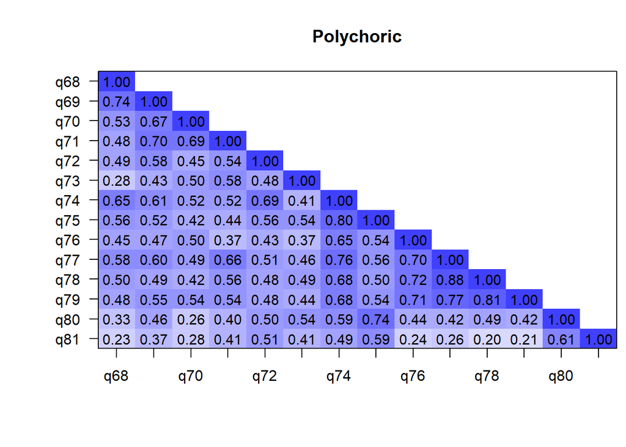

```r
poly <- polychoric(convos)
cor.plot(poly$rho, numbers = T, upper = F, main = "Polychoric", show.legend = F) # looks good, lower corr among items 80, 81, 73
```

## scree plot

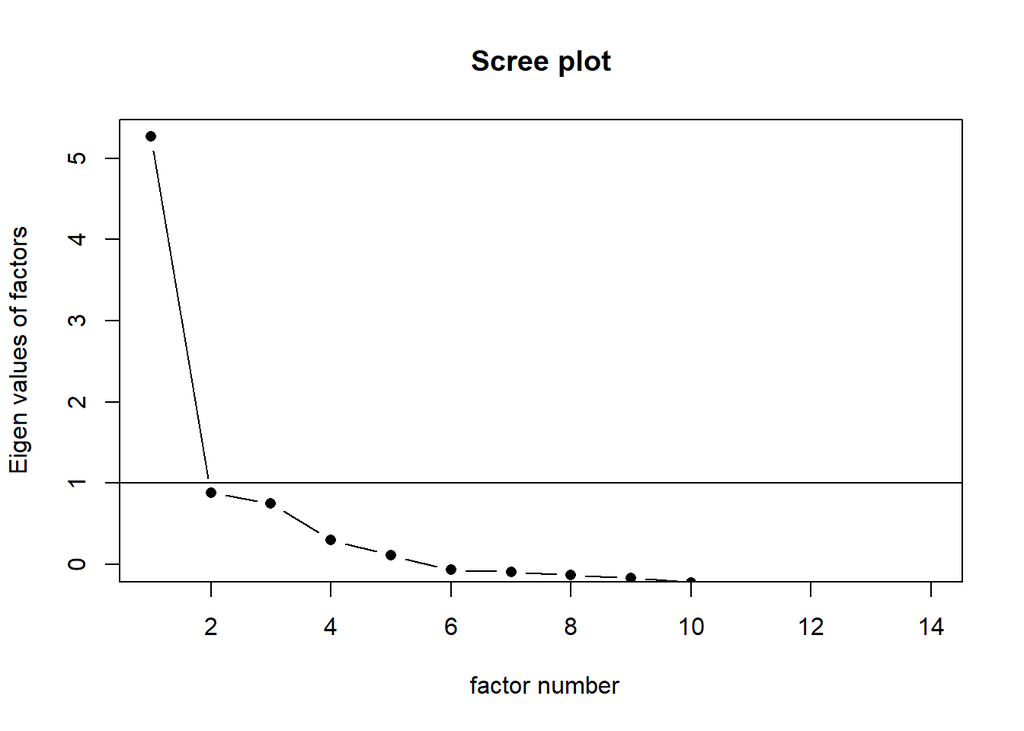

```r
scree(convos, factors = TRUE, pc = FALSE, main = "Scree plot", hline = NULL, add = FALSE)
```

```r
# Scree plot shows an almost 2 factor solution, but the second factor is a little less than 1.0 eigenvalue
```

## parallel test

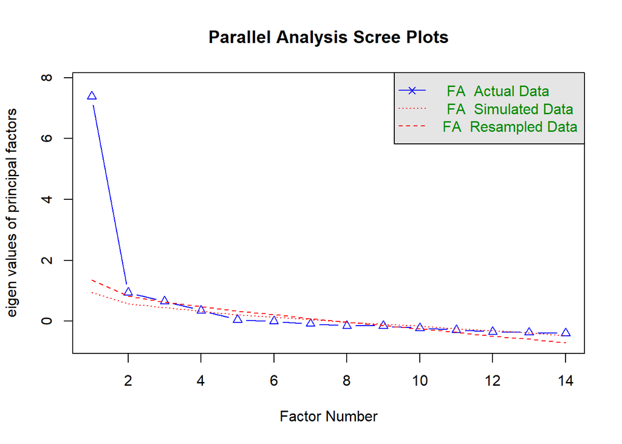

```
## Parallel analysis suggests that the number of factors =  3  and the number of components =  NA
```

```r
fa.parallel(convos, n.obs=NULL, fm="uls", fa="fa", main="Parallel Analysis Scree Plots", cor="poly", use="pairwise", plot=TRUE)
```

```r
# Parallel analysis suggests that the number of factors =  3
# warnings.
```

## EFA using ULS

```r
factor_test_uls <- fa(convos, n.obs = 95, rotate = "oblimin", fm = "uls", cor = "poly", nfactors = 3)
factor_test_uls
```

```
## Factor Analysis using method =  uls
## Call: fa(r = convos, nfactors = 3, n.obs = 95, rotate = "oblimin",
##     fm = "uls", cor = "poly")
## Standardized loadings (pattern matrix) based upon correlation matrix
##      ULS1  ULS3  ULS2   h2   u2 com
## q68  0.23  0.52  0.04 0.50 0.50 1.4
## q69  0.01  0.83  0.06 0.77 0.23 1.0
## q70  0.03  0.84 -0.09 0.66 0.34 1.0
## q71  0.04  0.77  0.05 0.68 0.32 1.0
## q72  0.10  0.36  0.41 0.54 0.46 2.1
## q73  0.09  0.31  0.36 0.41 0.59 2.1
## q74  0.49  0.14  0.41 0.78 0.22 2.1
## q75  0.24  0.02  0.73 0.79 0.21 1.2
## q76  0.75 -0.01  0.09 0.62 0.38 1.0
## q77  0.81  0.17 -0.02 0.85 0.15 1.1
## q78  0.96 -0.05  0.01 0.87 0.13 1.0
## q79  0.79  0.12 -0.01 0.75 0.25 1.0
## q80  0.14 -0.09  0.82 0.72 0.28 1.1
## q81 -0.26  0.16  0.79 0.60 0.40 1.3
##
##                       ULS1 ULS3 ULS2
## SS loadings           3.70 3.07 2.75
## Proportion Var        0.26 0.22 0.20
## Cumulative Var        0.26 0.48 0.68
## Proportion Explained  0.39 0.32 0.29
## Cumulative Proportion 0.39 0.71 1.00
##
##  With factor correlations of
##      ULS1 ULS3 ULS2
## ULS1 1.00 0.64 0.48
## ULS3 0.64 1.00 0.52
## ULS2 0.48 0.52 1.00
##
## Mean item complexity =  1.3
## Test of the hypothesis that 3 factors are sufficient.
##
## df null model =  91  with the objective function =  12.91 with Chi Square =  1142.97
## df of  the model are 52  and the objective function was  2.28
##
## The root mean square of the residuals (RMSR) is  0.05
## The df corrected root mean square of the residuals is  0.06
##
## The harmonic n.obs is  95 with the empirical chi square  38.79  with prob <  0.91
## The total n.obs was  95  with Likelihood Chi Square =  197.55  with prob <  8e-19
##
## Tucker Lewis Index of factoring reliability =  0.752
## RMSEA index =  0.171  and the 90 % confidence intervals are  0.147 0.198
## BIC =  -39.25
## Fit based upon off diagonal values = 0.99
## Measures of factor score adequacy
##                                                   ULS1 ULS3 ULS2
## Correlation of (regression) scores with factors   0.98 0.95 0.94
## Multiple R square of scores with factors          0.95 0.90 0.89
## Minimum correlation of possible factor scores     0.90 0.81 0.78
```

```r
# no warnings. some crossloading items
```

## removing crossloading items

72. … las cosas que aprende en clase.
73. … cómo contribuye al salón de clase.
74. … cómo va en sus clases.

```r
convos <- parent_w1 %>%
  select(q68, q69, q70, q71, q75, q76, q77, q78, q79, q80, q81)
```

## EFA using ULS

```r
factor_test_uls <- fa(convos, n.obs = 95, rotate = "oblimin", fm = "uls", cor = "poly", nfactors = 3)
factor_test_uls
```

```
## Factor Analysis using method =  uls
## Call: fa(r = convos, nfactors = 3, n.obs = 95, rotate = "oblimin",
##     fm = "uls", cor = "poly")
## Standardized loadings (pattern matrix) based upon correlation matrix
##      ULS1  ULS3  ULS2   h2    u2 com
## q68  0.17  0.58  0.04 0.52 0.481 1.2
## q69 -0.03  0.89  0.07 0.83 0.174 1.0
## q70  0.06  0.80 -0.09 0.63 0.367 1.0
## q71  0.10  0.69  0.06 0.63 0.374 1.1
## q75  0.18  0.10  0.71 0.75 0.247 1.2
## q76  0.71  0.03  0.11 0.62 0.385 1.1
## q77  0.79  0.19  0.00 0.84 0.158 1.1
## q78  0.99 -0.07  0.02 0.91 0.089 1.0
## q79  0.78  0.13  0.01 0.75 0.250 1.1
## q80  0.12 -0.09  0.87 0.79 0.214 1.1
## q81 -0.23  0.17  0.74 0.55 0.448 1.3
##
##                       ULS1 ULS3 ULS2
## SS loadings           3.15 2.66 2.01
## Proportion Var        0.29 0.24 0.18
## Cumulative Var        0.29 0.53 0.71
## Proportion Explained  0.40 0.34 0.26
## Cumulative Proportion 0.40 0.74 1.00
##
##  With factor correlations of
##      ULS1 ULS3 ULS2
## ULS1 1.00 0.62 0.47
## ULS3 0.62 1.00 0.50
## ULS2 0.47 0.50 1.00
##
## Mean item complexity =  1.1
## Test of the hypothesis that 3 factors are sufficient.
##
## df null model =  55  with the objective function =  9.44 with Chi Square =  844.58
## df of  the model are 25  and the objective function was  1.28
##
## The root mean square of the residuals (RMSR) is  0.04
## The df corrected root mean square of the residuals is  0.06
##
## The harmonic n.obs is  95 with the empirical chi square  17.9  with prob <  0.85
## The total n.obs was  95  with Likelihood Chi Square =  111.63  with prob <  6.4e-13
##
## Tucker Lewis Index of factoring reliability =  0.753
## RMSEA index =  0.191  and the 90 % confidence intervals are  0.157 0.229
## BIC =  -2.21
## Fit based upon off diagonal values = 0.99
## Measures of factor score adequacy
##                                                   ULS1 ULS3 ULS2
## Correlation of (regression) scores with factors   0.98 0.96 0.94
## Multiple R square of scores with factors          0.96 0.91 0.88
## Minimum correlation of possible factor scores     0.92 0.83 0.76
```

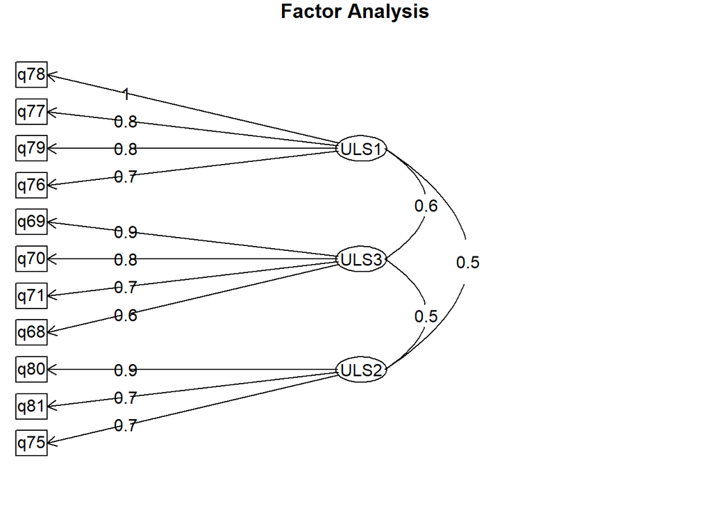

```r
fa.diagram(factor_test_uls)
```

```r
# no warnings. all loading above .30
```

## factor 1: school climate & behavior (not included in multiple regression analyses)

76. … desafíos que surgen en la escuela (como intimidación, agresión, acoso, racismo, peleas, etc.) ___
77. … sus actitudes sobre la escuela ____
78. … su comportamiento en la escuela ____
79. … las cosas que suceden en la escuela (el ambiente escolar en general) ____

```r
convos_climate <- parent_w1 %>%
  select(q76, q77, q78, q79)
# alpha
alpha(convos_climate) # 0.84
```

```
##
## Reliability analysis
## Call: alpha(x = convos_climate)
##
##   raw_alpha std.alpha G6(smc) average_r S/N   ase mean  sd median_r
##       0.84      0.85    0.82      0.58 5.5 0.027  3.5 0.6     0.56
##
##     95% confidence boundaries
##          lower alpha upper
## Feldt     0.78  0.84  0.88
## Duhachek  0.78  0.84  0.89
##
##  Reliability if an item is dropped:
##     raw_alpha std.alpha G6(smc) average_r S/N alpha se  var.r med.r
## q76      0.85      0.86    0.81      0.68 6.2    0.025 0.0021  0.67
## q77      0.77      0.78    0.72      0.55 3.6    0.041 0.0103  0.49
## q78      0.77      0.77    0.71      0.53 3.4    0.041 0.0078  0.49
## q79      0.78      0.79    0.74      0.56 3.9    0.039 0.0202  0.49
##
##  Item statistics
##      n raw.r std.r r.cor r.drop mean   sd
## q76 95  0.76  0.74  0.59   0.55  3.5 0.80
## q77 95  0.86  0.86  0.81   0.72  3.5 0.81
## q78 95  0.85  0.87  0.83   0.75  3.6 0.60
## q79 95  0.84  0.84  0.77   0.70  3.5 0.70
##
## Non missing response frequency for each item
##        1    2    3    4 miss
## q76 0.05 0.03 0.25 0.66    0
## q77 0.06 0.01 0.28 0.64    0
## q78 0.01 0.03 0.26 0.69    0
## q79 0.02 0.05 0.33 0.60    0
```

## factor 2: socialization/social support (not included in multiple regression analyses)

68. … sus amistades en la escuela. ___
69. … su participación en actividades escolares. ____
70. … eventos que van a pasar en la escuela. ___
71. … sus profesores. ___

```r
convos_social <- parent_w1 %>%
  select(q68, q69, q70, q71)
# alpha
alpha(convos_social) # 0.79
```

```
##
## Reliability analysis
## Call: alpha(x = convos_social)
##
##   raw_alpha std.alpha G6(smc) average_r S/N   ase mean   sd median_r
##       0.79       0.8    0.77      0.49 3.9 0.035  3.5 0.59     0.56
##
##     95% confidence boundaries
##          lower alpha upper
## Feldt     0.72  0.79  0.85
## Duhachek  0.73  0.79  0.86
##
##  Reliability if an item is dropped:
##     raw_alpha std.alpha G6(smc) average_r S/N alpha se   var.r med.r
## q68      0.80      0.80    0.73      0.58 4.1    0.035 0.00025  0.58
## q69      0.69      0.68    0.62      0.42 2.2    0.054 0.02351  0.37
## q70      0.73      0.73    0.69      0.48 2.8    0.049 0.02505  0.56
## q71      0.74      0.75    0.68      0.50 3.0    0.046 0.01234  0.56
##
##  Item statistics
##      n raw.r std.r r.cor r.drop mean   sd
## q68 95  0.69  0.71  0.56   0.48  3.6 0.69
## q69 95  0.85  0.86  0.81   0.72  3.5 0.70
## q70 95  0.82  0.80  0.70   0.63  3.4 0.82
## q71 95  0.79  0.78  0.69   0.61  3.4 0.78
##
## Non missing response frequency for each item
##        1    2    3    4 miss
## q68 0.02 0.05 0.25 0.67    0
## q69 0.01 0.08 0.34 0.57    0
## q70 0.06 0.02 0.38 0.54    0
## q71 0.04 0.05 0.37 0.54    0
```

## factor 3: future, prepping

```r
convos_college <- parent_w1 %>%
  select(q75, q80, q81)
# alpha
alpha(convos_college) # 0.77, removing item 81 would increase alpha, but scale would be only of 2 items.
```

```
##
## Reliability analysis
## Call: alpha(x = convos_college)
##
##   raw_alpha std.alpha G6(smc) average_r S/N   ase mean   sd median_r
##       0.77      0.77     0.7      0.53 3.4 0.042  3.2 0.72     0.48
##
##     95% confidence boundaries
##          lower alpha upper
## Feldt     0.67  0.77  0.84
## Duhachek  0.69  0.77  0.85
##
##  Reliability if an item is dropped:
##     raw_alpha std.alpha G6(smc) average_r S/N alpha se var.r med.r
## q75      0.64      0.64    0.47      0.47 1.7    0.074    NA  0.47
## q80      0.64      0.65    0.48      0.48 1.8    0.072    NA  0.48
## q81      0.78      0.78    0.64      0.64 3.6    0.044    NA  0.64
##
##  Item statistics
##      n raw.r std.r r.cor r.drop mean   sd
## q75 95  0.84  0.85  0.76   0.65  3.4 0.81
## q80 94  0.84  0.85  0.75   0.64  3.4 0.87
## q81 95  0.80  0.78  0.58   0.52  2.9 0.94
##
## Non missing response frequency for each item
##        1    2    3    4 miss
## q75 0.04 0.07 0.31 0.58 0.00
## q80 0.04 0.13 0.26 0.57 0.01
## q81 0.13 0.13 0.49 0.25 0.00
```

## Omega

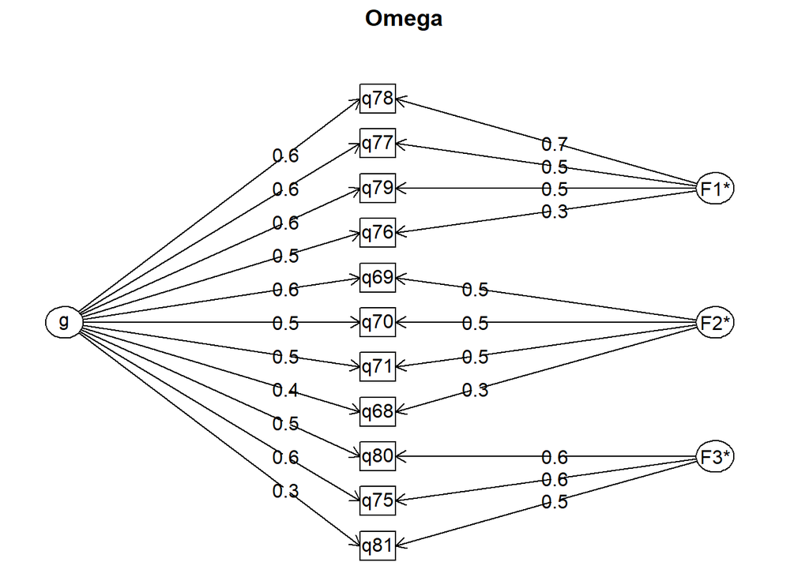

```
## Omega
## Call: omegah(m = m, nfactors = nfactors, fm = fm, key = key, flip = flip,
##     digits = digits, title = title, sl = sl, labels = labels,
##     plot = plot, n.obs = n.obs, rotate = rotate, Phi = Phi, option = option,
##     covar = covar)
## Alpha:                 0.86
## G.6:                   0.89
## Omega Hierarchical:    0.66
## Omega H asymptotic:    0.73
## Omega Total            0.91
##
## Schmid Leiman Factor loadings greater than  0.2
##        g   F1*   F2*   F3*   h2   h2   u2   p2  com
## q68 0.44        0.33       0.31 0.31 0.69 0.63 1.94
## q69 0.61        0.55       0.68 0.68 0.32 0.55 1.99
## q70 0.51        0.53       0.54 0.54 0.46 0.47 2.00
## q71 0.53        0.48       0.51 0.51 0.49 0.55 1.99
## q75 0.59              0.56 0.67 0.67 0.33 0.52 2.05
## q76 0.48  0.34             0.36 0.36 0.64 0.64 1.98
## q77 0.63  0.53             0.69 0.69 0.31 0.57 2.03
## q78 0.59  0.66             0.78 0.78 0.22 0.44 1.99
## q79 0.58  0.51             0.60 0.60 0.40 0.56 2.00
## q80 0.50              0.63 0.65 0.65 0.35 0.38 1.94
## q81 0.34              0.49 0.39 0.39 0.61 0.29 2.08
##
## With Sums of squares  of:
##    g  F1*  F2*  F3*   h2
## 3.13 1.13 0.96 0.98 3.73
##
## general/max  0.84   max/min =   3.89
## mean percent general =  0.51    with sd =  0.11 and cv of  0.21
## Explained Common Variance of the general factor =  0.5
##
## The degrees of freedom are 25  and the fit is  0.42
## The number of observations was  95  with Chi Square =  36.83  with prob <  0.06
## The root mean square of the residuals is  0.04
## The df corrected root mean square of the residuals is  0.06
## RMSEA index =  0.07  and the 10 % confidence intervals are  0 0.117
## BIC =  -77.01
##
## Compare this with the adequacy of just a general factor and no group factors
## The degrees of freedom for just the general factor are 44  and the fit is  1.93
## The number of observations was  95  with Chi Square =  171.87  with prob <  5.1e-17
## The root mean square of the residuals is  0.15
## The df corrected root mean square of the residuals is  0.17
##
## RMSEA index =  0.175  and the 10 % confidence intervals are  0.149 0.204
## BIC =  -28.5
##
## Measures of factor score adequacy
##                                                  g  F1*  F2*  F3*
## Correlation of scores with factors            0.82 0.77 0.72 0.77
## Multiple R square of scores with factors      0.67 0.59 0.52 0.60
## Minimum correlation of factor score estimates 0.34 0.17 0.04 0.19
##
##  Total, General and Subset omega for each subset
##                                                  g  F1*  F2*  F3*
## Omega total for total scores and subscales    0.91 0.85 0.80 0.79
## Omega general for total scores and subscales  0.66 0.47 0.44 0.33
## Omega group for total scores and subscales    0.21 0.38 0.36 0.46
```

```r
omega(convos, nfactors = 3, n.obs = 95, flip = T, plot = T) # .86 looks really beautiful.
```

# school involvement & others

En general, hago un esfuerzo para… 31. … conocer el personal y la administración de la escuela *32. … conocer al menos uno de los maestros de mi joven* _ 33. … entender las reglas y pólizas de la escuela ____ 34. … informarme sobre mis derechos como padre ____ 35. … aprender sobre el sistema educativo en este estado ____ 36. … entender la diferencia entre obtener un GED, graduarse con un diploma estándar de la escuela secundaria, o con un diploma de una secundaria internacional o con un diploma de Bachillerato Internacional._ *37. … involucrarse en las actividades escolares, en el salón de clase, y/u otras maneras (por ejemplo, organizaciones de padres, trabajo voluntario, etc.) 38. … tener conversaciones con los otros padres para obtener información o aprender acerca de los recursos en la escuela.* _ 39. …contactar los otros padres para obtener apoyo. ____ 40. …entender la trayectoria hacia la preparación a la universidad y para una carrera ____ 41. … asistir a la conferencia de padres y maestros cuando esté disponible. _____

## The scale to factor analyze

```r
scho_inv <- parent_w1 %>%
  select(q31, q32, q33, q34, q35, q36, q37, q38, q39, q40, q41)
```

## kmo Kaiser-Meyer-Olkin factor

```r
KMO(scho_inv) # 0.83
```

```
## Kaiser-Meyer-Olkin factor adequacy
## Call: KMO(r = scho_inv)
## Overall MSA =  0.83
## MSA for each item =
##  q31  q32  q33  q34  q35  q36  q37  q38  q39  q40  q41
## 0.83 0.80 0.82 0.88 0.85 0.86 0.87 0.77 0.84 0.84 0.69
```

## Poly corr matrix

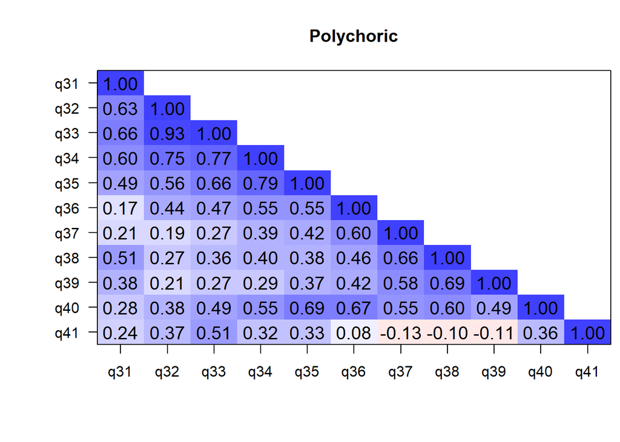

```r
poly <- polychoric(scho_inv)
cor.plot(poly$rho, numbers = T, upper = F, main = "Polychoric", show.legend = F) # item 41 with 37-39 neg corrs.
```

## scree plot

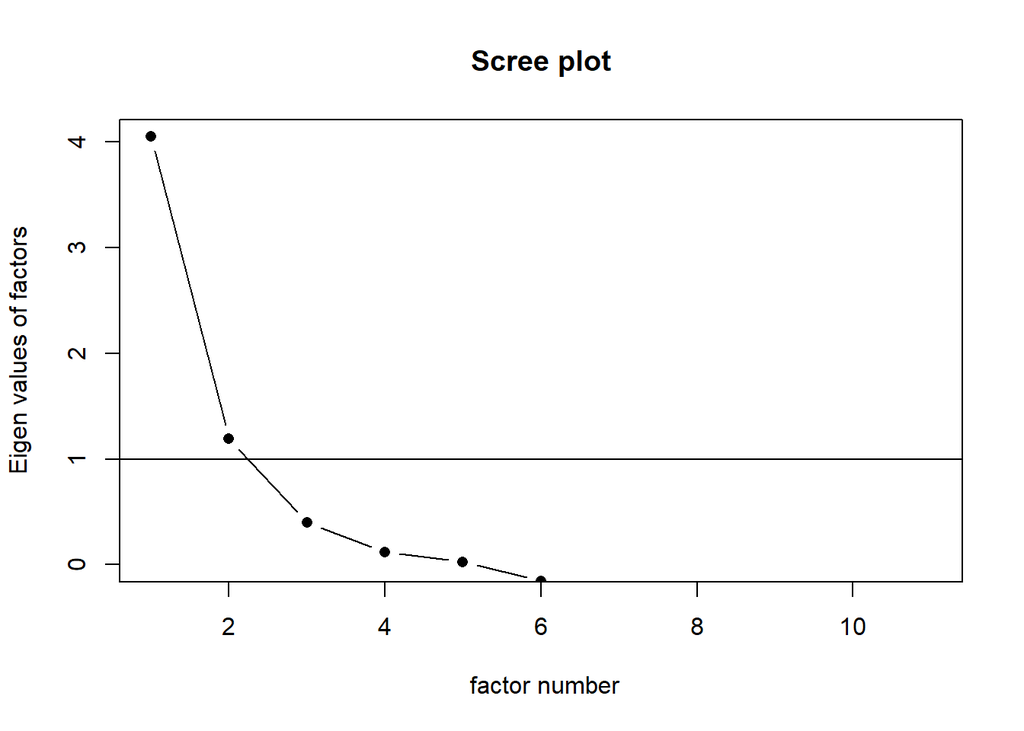

```r
scree(scho_inv, factors = TRUE, pc = FALSE, main = "Scree plot", hline = NULL, add = FALSE)
```

```r
# Scree plot  shows 2 factor solution
```

## parallel test

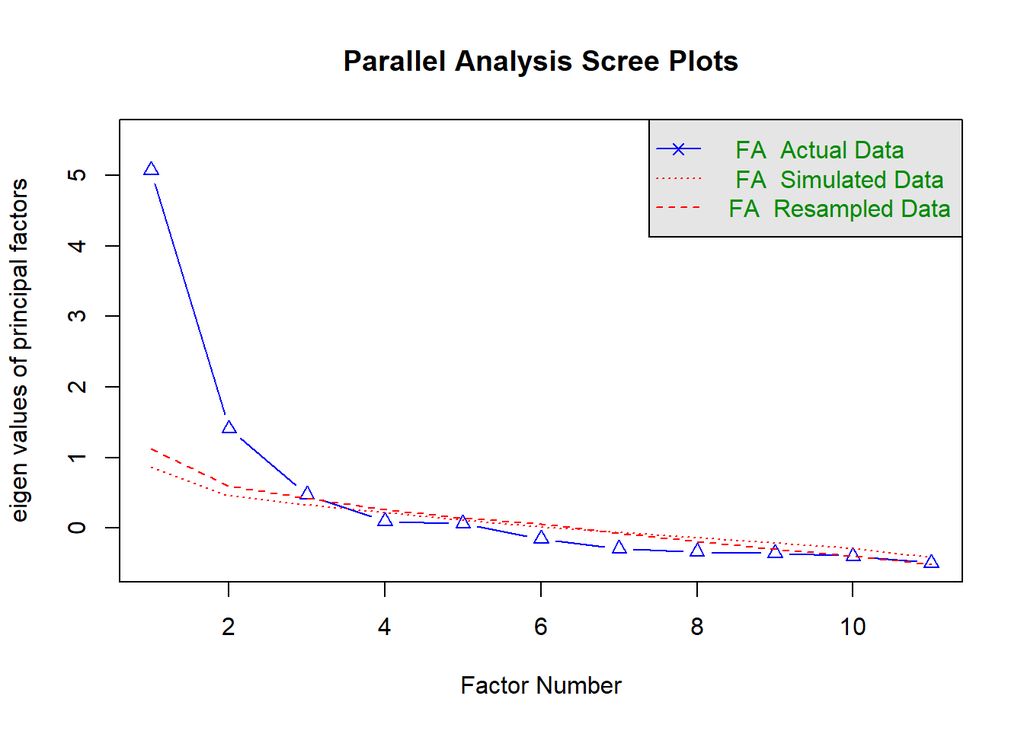

```
## Parallel analysis suggests that the number of factors =  3  and the number of components =  NA
```

```r
fa.parallel(scho_inv, n.obs=NULL, fm="uls", fa="fa", main="Parallel Analysis Scree Plots", cor="poly", use="pairwise", plot=TRUE)
```

```r
# Parallel analysis suggests that the number of factors =  3
```

## EFA using ULS

```r
factor_test_uls <- fa(scho_inv, n.obs = 95, rotate = "oblimin", fm = "uls", cor = "poly", nfactors = 2)
factor_test_uls
```

```
## Factor Analysis using method =  uls
## Call: fa(r = scho_inv, nfactors = 2, n.obs = 95, rotate = "oblimin",
##     fm = "uls", cor = "poly")
## Standardized loadings (pattern matrix) based upon correlation matrix
##      ULS1  ULS2   h2    u2 com
## q31  0.58  0.14 0.42 0.580 1.1
## q32  0.91 -0.07 0.78 0.224 1.0
## q33  0.98 -0.03 0.94 0.057 1.0
## q34  0.79  0.18 0.77 0.233 1.1
## q35  0.63  0.30 0.64 0.359 1.4
## q36  0.27  0.55 0.50 0.498 1.5
## q37 -0.07  0.86 0.69 0.313 1.0
## q38  0.03  0.81 0.68 0.318 1.0
## q39 -0.04  0.76 0.55 0.450 1.0
## q40  0.35  0.56 0.59 0.407 1.7
## q41  0.61 -0.31 0.32 0.684 1.5
##
##                       ULS1 ULS2
## SS loadings           3.88 2.99
## Proportion Var        0.35 0.27
## Cumulative Var        0.35 0.63
## Proportion Explained  0.56 0.44
## Cumulative Proportion 0.56 1.00
##
##  With factor correlations of
##      ULS1 ULS2
## ULS1 1.00 0.41
## ULS2 0.41 1.00
##
## Mean item complexity =  1.2
## Test of the hypothesis that 2 factors are sufficient.
##
## df null model =  55  with the objective function =  9.79 with Chi Square =  876.18
## df of  the model are 34  and the objective function was  2.65
##
## The root mean square of the residuals (RMSR) is  0.08
## The df corrected root mean square of the residuals is  0.1
##
## The harmonic n.obs is  94 with the empirical chi square  61.07  with prob <  0.003
## The total n.obs was  95  with Likelihood Chi Square =  233.47  with prob <  1.3e-31
##
## Tucker Lewis Index of factoring reliability =  0.601
## RMSEA index =  0.248  and the 90 % confidence intervals are  0.22 0.281
## BIC =  78.64
## Fit based upon off diagonal values = 0.98
```

```r
# warnings
# items 35, 40, 41 crossload
```

## Removing crossloading items 35, 40, 41

```r
scho_inv <- parent_w1 %>%
  select(q31, q32, q33, q34, q36, q37, q38, q39)
```